# Week 7 Homework

Author

Andrew Joyce

Published

October 16, 2023

## 7.1.1. Exercise

```r
tabyl(d1, weekly, conservative) |> adorn_totals(c("row", "col") )
```

```
 weekly    0   1 Total
      0 1243 495  1738
      1  257 240   497
  Total 1500 735  2235
```

```r
tabyl(d1, weekly) ## for answers #1 and #2
```

```
 weekly    n   percent
      0 1738 0.7776286
      1  497 0.2223714
```

```r
tabyl(d1, conservative) # for answer number 8
```

```
 conservative    n   percent
            0 1500 0.6711409
            1  735 0.3288591
```

1. $\Pr(W)$ = 0.22
2. $\Pr(W^C)$ = 0.77

```r
# to answer #3 and #5
tabyl(d1, weekly, conservative) |>
  adorn_percentages() |>
  adorn_pct_formatting(digits = 0)
```

```
 weekly   0   1
      0 72% 28%
      1 52% 48%
```

```r
# to answer #4
tabyl(d1, weekly, conservative) |>
  adorn_percentages(denominator = "col") |>
  adorn_pct_formatting(digits = 0)
```

```
 weekly   0   1
      0 83% 67%
      1 17% 33%
```

3. $\Pr(C \mid W)$ = 0.48
4. $\Pr(W \mid C)$ = 0.33
5. $\Pr(C \mid W^\complement)$ = 0.28

```r
# for answers to #6 and #7
tabyl(d1, weekly, conservative) |>
  adorn_percentages(denominator = "all") |>
  adorn_pct_formatting(digits = 0)
```

```
 weekly   0   1
      0 56% 22%
      1 11% 11%
```

6. $\Pr(W \text{ and } C)$ = 0.11
7. $\Pr(W^\complement \text{ and } C^\complement)$ = 0.56
8. If we assume $W$ and $C$ are independent, what *would* be their joint probability?

Events $W$ and $C$ are Independent if and only if the joint probability is equal to the product of the marginal probabilities. That is, $\Pr(W \text{ and } C) = \Pr(W)Pr(C)$.

Since $\Pr(W)$ = 0.22 and $\Pr(C)$ = 0.33, we should expect the joint probability to be $0.22 * 0.33$, or 0.0726

Thus, the **expected joint probability assuming independence = 0.0726, or 7.26%.**

## 7.1.2 Exercise

DiPrete and Buchmann (2013) find that women outnumber men in terms of bachelor’s degree completion. So, I am going to compare sex ($F$ = female, $F^\complement$=male) and completion of a bachelor’s degree or higher ( $D$ ).

```r
# data prep
library(gssr)
gss18v2 <- gss_get_yr(2018) |>
  haven::zap_labels()
```

```
Fetching: https://gss.norc.org/documents/stata/2018_stata.zip
```

```r
d2 <- gss18v2 |>
  select(sex, degree) |>
  drop_na() |>
  mutate(female = if_else(sex == 2, 1L, 0L),
         sex = if_else(female == 1, "Female", "Male"),
         degree = if_else(degree >= 3, 1L, 0L),
         degree_chr = if_else(degree == 1, "Bachelor's or Higher", "Less than Bachelor's")) |>
  relocate(sex, female, degree_chr, degree)
```

```r
# contingency table
tabyl(d2, sex, degree_chr) |>
  adorn_totals(c("row", "col")) |>
  adorn_percentages(denominator = "all") |>
  adorn_pct_formatting(digits = 0) |>
  adorn_ns()
```

```
    sex Bachelor's or Higher Less than Bachelor's        Total
 Female            17% (396)          38%   (900)  55% (1,296)
   Male            13% (316)          31%   (736)  45% (1,052)
  Total            30% (712)          70% (1,636) 100% (2,348)
```

I will show relevant code below, but I will input the answers to the questions in the table here.

Notation

Translation

Probability

1. $\Pr(D)$

Probability of completing a bachelor’s degree or higher

0.30 or 30%

2. $\Pr(D^\complement)$

Probability of not completing a bachelor’s degree or higher

0.70 or 70%

3. $\Pr(F \mid D)$

Probability of being female given completion a college degree (note that this is a nonsense prediction)

0.56 or 56%

4. $\Pr(D \mid F)$

Probability of completing a college degree given respondent is female

0.31 or 31%

5. $\Pr(D \mid F^\complement)$

Probability of completing a college degree given respondent is male (literally, not female)

0.30 or 30%

6. $\Pr(D \text{ and } F)$

Joint probability of completing a college degree and female

0.17 or 17%

7. $\Pr(D^\complement \text{ and } F^\complement)$

Joint probability of not completing a college degree and male

0.31 or 31%

8. Expected $\Pr(D \text{ and } F)$ given independence.

Assuming sex and degree completion are independent, what would we expect the joint probability to be?

Expected $\Pr(D \text{ and } F)$ given independence:

$Pr(D) * Pr(F)$ = $0.30 * 0.55$ = $0.165$

or **16.5% assuming independence**

```r
# for 1 & 2 and #8
tabyl(d2, degree)
```

```
 degree    n   percent
      0 1636 0.6967632
      1  712 0.3032368
```

```r
tabyl(d2, female)
```

```
 female    n   percent
      0 1052 0.4480409
      1 1296 0.5519591
```

```r
# to answer #3  (Pr(F | D))
tabyl(d2, degree, female) |>
  adorn_percentages() |>
  adorn_pct_formatting(digits = 0)
```

```
 degree   0   1
      0 45% 55%
      1 44% 56%
```

```r
# to answer #4 and 5 (Pr(D | F) and Pr (D | F^C))
tabyl(d2, degree, female) |>
  adorn_percentages(denominator = "col") |>
  adorn_pct_formatting(digits = 0)
```

```
 degree   0   1
      0 70% 69%
      1 30% 31%
```

```r
# to answer #7 (Pr(D & F))
tabyl(d2, degree, female) |>
  adorn_percentages(denominator = "all") |>
  adorn_pct_formatting(digits = 0)
```

```
 degree   0   1
      0 31% 38%
      1 13% 17%
```

## 7.2.1 Exercise

Comparing the probabilities of $\Pr(W \mid C)$ and $\Pr(W \mid C^\complement)$

- $\Pr(W \mid C)$ = 0.33
- $\Pr(W \mid C^\complement)$ = 0.17

| Method | Result |
| --- | --- |
| Difference in Probabilities | 0.16 or 16% (probability of weekly attendance for conservatives is 16% greater than the probability of weekly attendance for those who are not conservatives) |
| Relative Risk Ratio | 1.94 (probability of weekly attendance is 1.94 times greater for conservatives than for those who are not conservatives) |
| Odds Ratio | 2.35 (the odds of weekly attendance are 2.35 times greater for conservatives than for those who are not conservatives) |
| Log Odds ratio | 0.85 (the log-odds of weekly attendance are 0.85 units higher for conservatives than for those who are not conservative) |

```r
# diff in probabilities
0.33 - 0.17
```

```
[1] 0.16
```

```r
# relative risk ratio
0.33/0.17
```

```
[1] 1.941176
```

```r
# odds ratio
(1243 * 240)/(257 * 495)
```

```
[1] 2.345006
```

```r
# log-odds ratio
log((1243 * 240)/(257 * 495))
```

```
[1] 0.8522882
```

## 7.2.2 Exercise

1. Draw a sampling distribution for the relative risk ratio `(stat = "ratio of props")`

```r
boot1 <- d1 |>
  mutate(conservative = if_else(conservative == 1L, "conservative", "other")) |>
  mutate(weekly = if_else(weekly == 1L, "weekly", "other")) |>
  specify(response = weekly, explanatory = conservative, success = "weekly") |>
  generate(reps = 1e4, type = "bootstrap") |>
  calculate(stat = "ratio of props", order = c("conservative", "other"))

ci <- get_confidence_interval(boot1)
```

```
Using `level = 0.95` to compute confidence interval.
```

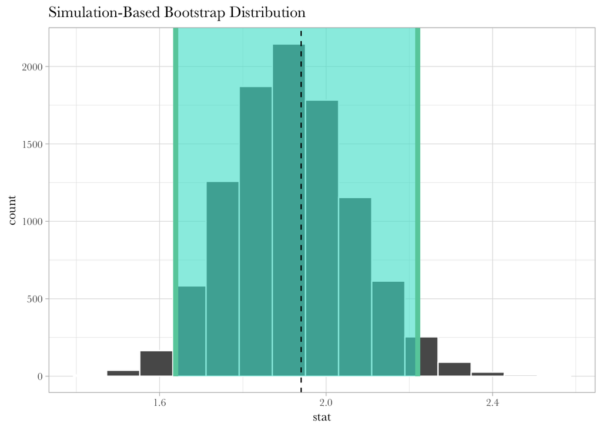

```r
boot1 |>
  visualize() +
  shade_ci(ci) +
  geom_vline(xintercept = 1.94, linetype = "dashed") # this is the value I hand-calculated in 7.2.1
```

2. Draw a sampling distribution for the odds-ratio

```r
boot1 <- d1 |>
  mutate(conservative = if_else(conservative == 1L, "conservative", "other")) |>
  mutate(weekly = if_else(weekly == 1L, "weekly", "other")) |>
  specify(response = weekly, explanatory = conservative, success = "weekly") |>
  generate(reps = 1e4, type = "bootstrap") |>
  calculate(stat = "odds ratio", order = c("conservative", "other"))

ci <- get_confidence_interval(boot1)
```

```
Using `level = 0.95` to compute confidence interval.
```

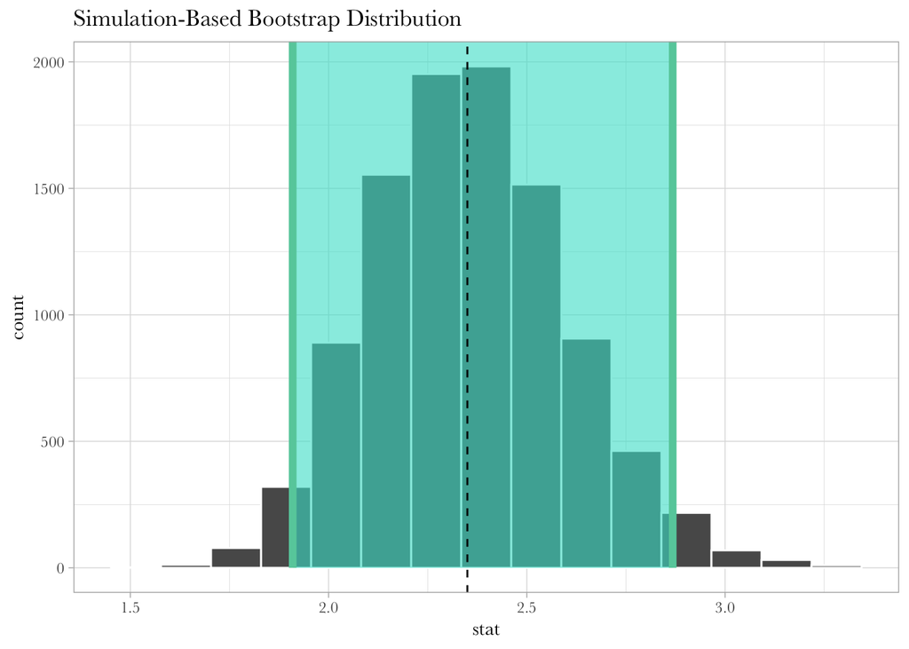

```r
boot1 |>
  visualize() +
  shade_ci(ci) +
  geom_vline(xintercept = 2.35, linetype = "dashed") # this is the value I hand-calculated in 7.2.1
```

## 7.2.3 Exercise

Comparing the probabilities of $\Pr(D \mid F)$ and $\Pr(D \mid F^\complement)$

- $\Pr(D \mid F)$ = 0.31 (Probability of college degree completion, given female)
- $\Pr(D \mid F^\complement)$ = 0.30 (Probability of college degree completion, given male)

[output not shown]

*Note: I suspect these differences are low because the GSS samples adults of all ages (18-89). The findings from DiPrete and Buchmann (2013) are of newer cohorts.*

```r
# diff in probabilities
0.31 - 0.30
```

```
[1] 0.01
```

```r
# relative risk ratio
0.31/0.30
```

```
[1] 1.033333
```

```r
# odds ratio
(396 * 736)/(900 * 316)
```

```
[1] 1.02481
```

```r
# log-odds ratio
log((396 * 736)/(900 * 316))
```

```
[1] 0.02450735
```

## 7.2.4 Exercise

1. Draw a sampling distribution for the relative risk ratio `(stat = "ratio of props")`

```r
boot2 <- d2 |>
  mutate(female = if_else(female == 1L, "women", "men")) |>
  mutate(degree = if_else(degree == 1L, "degree", "other")) |>
  specify(response = degree, explanatory = female, success = "degree") |>
  generate(reps = 1e4, type = "bootstrap") |>
  calculate(stat = "ratio of props", order = c("women", "men"))

ci <- get_confidence_interval(boot2)
```

```
Using `level = 0.95` to compute confidence interval.
```

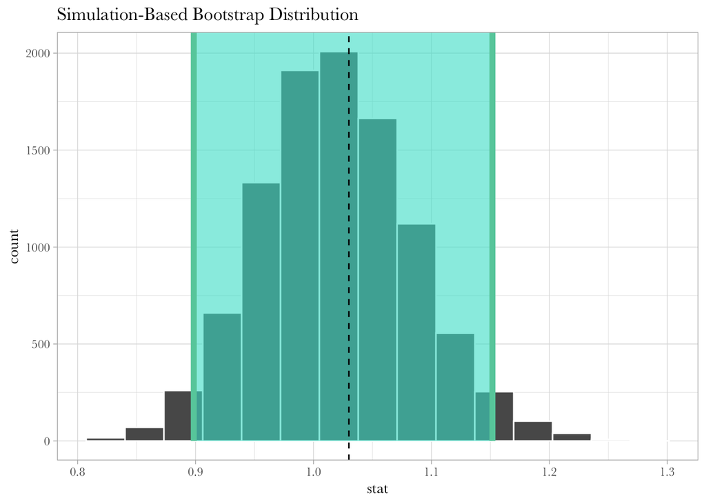

```r
boot2 |>
  visualize() +
  shade_ci(ci) +
  geom_vline(xintercept = 1.03, linetype = "dashed") # this is the value I hand-calculated in 7.2.3
```

2. Draw a sampling distribution for the odds ratio.

```r
boot2 <- d2 |>
  mutate(female = if_else(female == 1L, "women", "men")) |>
  mutate(degree = if_else(degree == 1L, "degree", "other")) |>
  specify(response = degree, explanatory = female, success = "degree") |>
  generate(reps = 1e4, type = "bootstrap") |>
  calculate(stat = "odds ratio", order = c("women", "men"))

ci <- get_confidence_interval(boot2)
```

```
Using `level = 0.95` to compute confidence interval.
```

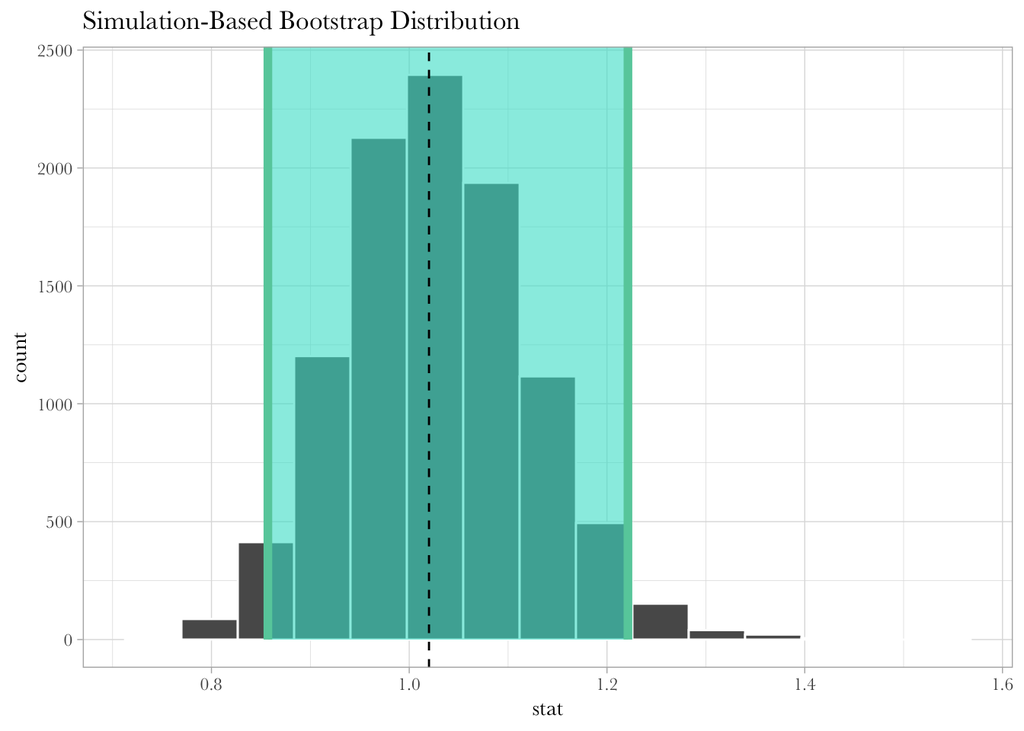

```r
boot2 |>
  visualize() +
  shade_ci(ci) +
  geom_vline(xintercept = 1.02, linetype = "dashed") # this is the value I hand-calculated in 7.2.3
```

## References

DiPrete, Thomas A., and Claudia Buchmann. 2013. *The Rise of Women: The Growing Gender Gap in Education and What It Means for American Schools*. New York: Russell Sage Foundation.